# ROBUST_presentation_2 slides

## MOVING TO NEURAL NETWORKS

Possibility of adversarial examples in deep neural networks

$h_\theta(x) : \mathbb{R}^n \rightarrow \mathbb{R}^k$ to be an $d$-layer network, given by the following equations \begin{equation} \begin{split} z_1 & = x \\ z_{i+1} & = f_i(W_i z_i + b_i), \;\; i,\ldots,d \\ h_\theta(x) & = z_{d+1} \end{split} \end{equation}

- where $z_i$ denote the activations at layer $i$;
- $f_i$ denotes the activation function for layer $i$, which we will often take to be e.g.
  - the ReLU operator $f_i(z) = \max\{0,z\}$ for layers $i=1,\ldots,d-1$ and
  - the linear operator $f_i(z) = z$ for layer $d$;
- and the parameters of the network are given by $\theta = \{W_1,b_1,\ldots,W_d,b_d\}$
- We assume that the size of all the intermediate layers are specified such that
  - the final function $h_\theta$ takes inputs in $\mathbb{R}^n$ and
  - outputs vectors in $\mathbb{R}^k$
- The loss function for multiclass case (Cross Entropy loss) is: \begin{equation} \ell(h_\theta(x), y) = \log \left ( \sum_{j=1}^k \exp(h_\theta(x)_j) \right ) - h_\theta(x)_y. \end{equation}

## Crafting an attack

*Not* easy to solve, the maximization problem

- cost surface for neural networks (over the *input* iso parameter space)
  - is not convex, and
  - is especially prone to local optima.

Solving the inner optimization problem \begin{equation} \DeclareMathOperator*{\maximize}{maximize} \maximize_{\|\delta\| \leq \epsilon} \ell(h_\theta(x + \delta), y) \end{equation} in the case of $h_\theta$ being a neural network:

- *any* feasible $\delta$ will give us a lower bound
  - "Find an adversarial example"
  - To approximate the pertubation
  - To find a *lower bound* on the optimization objective
  - Equivalent to just "trying to empirically solve the optimization problem"

## Lower bounding inner maximization (adversarial attacks)

Solving the optimization problem is the task of maximizing \begin{equation} \DeclareMathOperator*{\maximize}{maximize} \maximize_{\|\delta\| \leq \epsilon} \ell(h_\theta(x + \delta), y). \end{equation}

Using backpropagation, compute the gradient of the loss function with respect to the perturbation $\delta$

- perform gradient descent on $\delta$ to maximize our objective
- ensure that $\delta$ stays within the norm bound $\epsilon$, so
- after each step, we can project back into this space

### The Fast Gradient Sign Method (FGSM)

- Compute the gradient (expressed in terms of $\delta$) using simple backpropagation \begin{equation} g := \nabla_\delta \ell(h_\theta(x + \delta),y) \end{equation}

In order to maximize loss

- adjust $\delta$ in direction of this gradient for some step size $\alpha$ \begin{equation} \delta := \delta + \alpha g \end{equation}
- then project back into the norm ball defined by $\|\delta\| \leq \epsilon$.

How big a step do we take? (Case of $\ell_\infty$ norm $\|\delta\|_\infty \leq \epsilon$)

- Clipping values of $\delta$ to lie within the range $[-\epsilon, \epsilon]$
- If our initial $\delta$ is zero, to increase the loss as much as possible, update \begin{equation} \delta := \mathrm{clip}(\alpha g, [-\epsilon, \epsilon]). \end{equation}
  - Take step $\alpha$ to be very large (projecting back into the $\ell_\infty$ ball afterwards)
  - For $\alpha$ large enough, the relative sizes of the entries of $g$ won't matter:
    - We will simply take $\delta_i$ to be either $+\epsilon$ or $-\epsilon$ depending upon the sign of $g_i$.
    - \begin{equation} \delta := \epsilon \cdot \mathrm{sign}(g). \end{equation}

### Initial construction of adversarial examples in deep learning community

#### Define a neural network with 3 fully connected layers

```python
class FCModel(torch.nn.Module):

  def __init__(self):
    super(FCModel, self).__init__()

    self.fc1 = nn.Linear(16, 12)
    self.fc2 = nn.Linear(12, 10)
    self.fc3 = nn.Linear(10, 1)

  def forward(self, x):

    x = F.relu(self.fc1(x))
    x = F.relu(self.fc2(x))
    x = self.fc3(x)

fcmodel = FCModel()

fccriterion = torch.nn.CrossEntropyLoss()
```

```python
print(model)
params = list(model.parameters())
print(len(params))
print(params[0].size())
```

```
ConvModel(
  (conv1): Conv2d(3, 32, kernel_size=(3, 3), stride=(1, 1), padding=(1, 1))
  (relu): ReLU()
  (pool): MaxPool2d(kernel_size=2, stride=2, padding=0, dilation=1, ceil_mode=False)
  (conv2): Conv2d(32, 64, kernel_size=(3, 3), stride=(1, 1), padding=(1, 1))
  (lin1): Linear(in_features=4096, out_features=1000, bias=True)
  (lin2): Linear(in_features=1000, out_features=120, bias=True)
  (lin3): Linear(in_features=120, out_features=10, bias=True)
  (d_out): Dropout(p=0.2, inplace=False)
)
10
torch.Size([32, 3, 3, 3])
```

```python
#from google.colab import drive
#drive.mount('/content/drive')


def eval_model(model, loader, attack=None):
  """Function to evaluate your model on a specific loader"""
  accuracy = 0.
  n_inputs = 0.
  for n_batch, (imgs, labels) in enumerate(loader):
      if cuda:
        imgs, labels = imgs.cuda(), labels.cuda()
      if attack==None:
        outputs = model(imgs)
      else:
        outputs = model(imgs + attack.compute(imgs, labels))
      predicted = outputs.argmax(axis=1)
      n_inputs += outputs.size(0)
      accuracy += (predicted == labels).sum()
  accuracy = accuracy/n_inputs
  print("Accuracy: ", accuracy)


eval_model(model, test_loader)
```

```
Accuracy:  tensor(0.8605)
```

#### Code the FGSM attack

```python
def fgsm_attack(image, epsilon, data_grad):
    # get the -wise sign of the data gradient
    sign_data_grad = data_grad.sign()
    # Create the perturbed image by adjusting each pixel of the input image
    perturbed_image = image + epsilon*sign_data_grad

    return perturbed_image
```

#### Plot some images with and without the adversarial perturbation

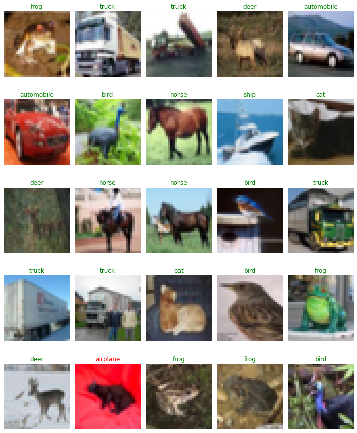

Clip should limit the values in an array.

Given an interval, values outside the interval would be clipped to the interval edges.

The model should be: 2x (conv -> max pooling -> relu) -> 2x (fc -> relu) -> fc.

There's no need to apply the softmax here because it will be in the cross entropy loss too.

### Projected gradient descent

Iterating it with a smaller step size

"basic iterative procedure": Gradient *ascent*: maximizing a function

The basic PGD algorithm simply iterates the updates: \begin{equation} \begin{split} & \mbox{Repeat:} \\ & \quad \delta := \mathcal{P}(\delta + \alpha \nabla_\delta \ell(h_\theta(x+\delta), y)) \end{split} \end{equation} where $\mathcal{P}$ denotes the projection onto the ball of interest (for example, clipping in the case of the $\ell_\infty$ norm).

Choices we need to make when specifying the attack, such as

- the actual stepsize itself, and
- the number of iterations
- (momentum)

[figure not shown]

Attack the pig image and plot the perturbation.

```python
label = pred.max(1)
_, label = torch.max(pred, 1)

# Obtaining the original prediced label to be used as input for the pgd function
label


pgd = ProjectedGradientDescent(model, 0.03, 0.0001, 100)

attacked_images=pgd.compute(norm(pig_tensor),label)
attacked_output = model(attacked_images)
print(
    "result of the attack",imagenet_classes[
        attacked_output.max(dim=1)[1].item()])
```

```
result of the attack boa_constrictor
```

```
WARNING:matplotlib.image:Clipping input data to the valid range for imshow with RGB data ([0..1] for floats or [0..255] for integers).
```

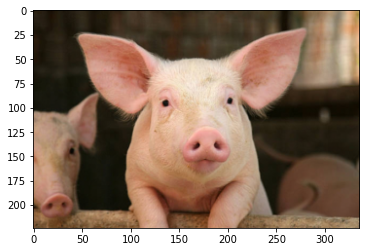

```python
# plot the beginning image

plt.imshow(unnorm(attacked_images)[0].numpy().transpose(1,2,0))
plt.show()
```